# BOOTSTRAP AND JACKKNIFE

23 Mar 2021 (*updated: 2021-03-23)*

## i. Week 9 Focus

- Students Practice on Ch. 7 content.
- Students receive and act on Ch. 6 feedback.
- Read Resampling techniques Ch. 8, 9.
- Discuss Resampling techniques Ch. 8, 9.

## Any questions on Ch.7 HW?

- 7.1 Trimmed mean
- 7.3 Power of \(t-test\)
- 7.5 Run length encoding
- 7.6 robustness of \(t-interval\)
- 7.10 Gini index (Note: Bernoulli(0.1) can produce sample means of 0, which yields a Gini index of `NaN`)
- Project 7.D. (mvn tests of normality ; see `mlbench` package)

## Today’s plan

1. Open with questions on Ch. 8 Problem Set to prime learning.
2. Discuss Ch. 8 the boostrap
3. Summarize, conclude, revisit Ch. 8 Problem prompt discussion / hints time remaining

*Please contribute questions and comments*

## Ch. 8 Bootstrap and Jackknife Overview

- 8.1 The Bootstrap
- 8.2 The Jackknife
- 8.3 Bootstrap Confidence Intervals
- 8.4 Better Bootstrap CIs
- 8.5 Application: Cross Validation

## I. Ch.8, Ch.9 HW

- 8.7 (Uncertainty in PCA variation explained)
- 8.8 (Compare bootstrap and jackknife PCA)
- 8.9 (Construct bootstrap CIs PCA)
- 8.10, 8.11 (Cross Validation: Model selection via prediction)
- 9.4, 9.5, 9.6 (Resampling simple linear regression)

## II. 8.1 The Bootstrap

- Discuss motivation on p.214
- Sample with replacement of size \(n\).

## Example 8.1

- Discuss briefly.

## 8.1.1 Bootstrap Estimation of Standard Error

- Discuss (8.1) on p.215

## Example 8.2 (Bootstrap estimate of SE)

```r
library(bootstrap)    ## for the law data
print(cor(law$LSAT, law$GPA))
```

```
## [1] 0.7763745
```

```r
print(cor(law82$LSAT, law82$GPA))
```

```
## [1] 0.7599979
```

## Example 8.2 (Bootstrap estimate of SE)

```r
## set up the bootstrap
B <- 200            ## number of replicates
n <- nrow(law)      ## sample size
R <- numeric(B)     ## storage for replicates
## bootstrap estimate of standard error of R
for (b in 1:B) {
    ## randomly select the indices
    i <- sample(1:n, size = n, replace = TRUE)
    LSAT <- law$LSAT[i]       ## i is a vector of indices
    GPA <- law$GPA[i]
    R[b] <- cor(LSAT, GPA)
}
## output
print(se.R <- sd(R))
```

```
## [1] 0.1322082
```

## Example 8.2 (Bootstrap estimate of SE)

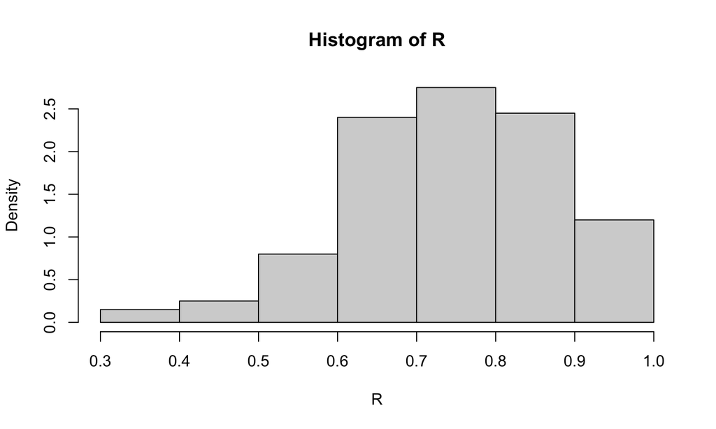

```r
hist(R, prob = TRUE)
```

## Example 8.3 (SE estimate via `boot` )

```r
r <- function(x, i) {
    ## want correlation of columns 1 and 2
    cor(x[i,1], x[i,2])
}
library(boot)       ## for boot function
obj <- boot(data = law, statistic = r, R = 2000)
```

## Example 8.3 (SE estimate via `boot` )

```r
obj
```

```
##
## ORDINARY NONPARAMETRIC BOOTSTRAP
##
##
## Call:
## boot(data = law, statistic = r, R = 2000)
##
##
## Bootstrap Statistics :
##      original       bias    std. error
## t1* 0.7763745 -0.006986028   0.1304005
```

```r
y <- obj$t
sd(y)
```

```
## [1] 0.1304005
```

## 8.1.2 Bootstrap Estimation of Bias

- The sample mean of the replicates is unbiased for *its* expected value \(E[\hat{\theta^*}]\).
- Equation (8.2)

## Example 8.4 (Bootstrap estimate of bias)

```r
## sample estimate for n=15
theta.hat <- cor(law$LSAT, law$GPA)
## bootstrap estimate of bias
B <- 2000   ## larger for estimating bias
n <- nrow(law)
theta.b <- numeric(B)
for (b in 1:B) {
    i <- sample(1:n, size = n, replace = TRUE)
    LSAT <- law$LSAT[i]
    GPA <- law$GPA[i]
    theta.b[b] <- cor(LSAT, GPA)
}
bias <- mean(theta.b - theta.hat)
bias
```

```
## [1] -0.00728881
```

## Example 8.5 (Bootstrap bias of a ratio estimator)

```r
data(patch, package = "bootstrap")
head(patch)
```

| subject | placebo | oldpatch | newpatch | z | y |
| --- | --- | --- | --- | --- | --- |
| 1 | 9243 | 17649 | 16449 | 8406 | -1200 |
| 2 | 9671 | 12013 | 14614 | 2342 | 2601 |
| 3 | 11792 | 19979 | 17274 | 8187 | -2705 |
| 4 | 13357 | 21816 | 23798 | 8459 | 1982 |
| 5 | 9055 | 13850 | 12560 | 4795 | -1290 |
| 6 | 6290 | 9806 | 10157 | 3516 | 351 |

## Example 8.5 (Bootstrap bias of a ratio estimator)

```r
n <- nrow(patch)  ## in bootstrap package
B <- 2000
theta.b <- numeric(B)
theta.hat <- mean(patch$y) / mean(patch$z)
## bootstrap
for (b in 1:B) {
    i <- sample(1:n, size = n, replace = TRUE)
    y <- patch$y[i]
    z <- patch$z[i]
    theta.b[b] <- mean(y) / mean(z)
}
bias <- mean(theta.b) - theta.hat
se <- sd(theta.b)
```

## Example 8.5 (Bootstrap bias of a ratio estimator)

```r
print(list(est=theta.hat, bias = bias,
           se = se, cv = bias/se))
```

```
## $est
## [1] -0.0713061
##
## $bias
## [1] 0.01078126
##
## $se
## [1] 0.107189
##
## $cv
## [1] 0.1005818
```

## III. 8.2 The Jackknife

- Difference between bootstrap
- Discuss “plug-in” \(\hat{\theta}\) as a smooth estimator.

## Jackknife Estimation of Bias

- Discuss (8.3)

## Example 8.6 (Jackknife estimate of bias)

```r
data(patch, package = "bootstrap")
n <- nrow(patch)
y <- patch$y
z <- patch$z
theta.hat <- mean(y) / mean(z)
print (theta.hat)
```

```
## [1] -0.0713061
```

## Example 8.6 (Jackknife estimate of bias)

```r
## compute the jackknife replicates, leave-one-out estimates
theta.jack <- numeric(n)
for (i in 1:n)
    theta.jack[i] <- mean(y[-i]) / mean(z[-i])
bias <- (n - 1) * (mean(theta.jack) - theta.hat)
print(bias)  ## jackknife estimate of bias
```

```
## [1] 0.008002488
```

## Jackknife Estimation of SE

- Discuss (8.4)

## Example 8.7 (Jackknife estimate of SE)

```r
se <- sqrt((n-1) *
           mean((theta.jack - mean(theta.jack))^2))
print(se)
```

```
## [1] 0.1055278
```

## When the jackknife fails

- When estimator is not smooth, “plug-in”
- perturbations greatly increase variance
- Try the delete-\(d\) jackknife instead. Or just bootstrap.

## Example 8.8 (Failure of jackknife)

```r
n <- 10
x <- sample(1:100, size = n)

## jackknife estimate of se
M <- numeric(n)
for (i in 1:n) {        ## leave one out
    y <- x[-i]
    M[i] <- median(y)
}
Mbar <- mean(M)
print(sqrt((n-1)/n * sum((M - Mbar)^2)))
```

```
## [1] 4.5
```

## Example 8.8 (Failure of jackknife)

```r
## bootstrap estimate of se
Mb <- replicate(1000, expr = {
    y <- sample(x, size = n, replace = TRUE)
    median(y) })
print(sd(Mb))
```

```
## [1] 13.54837
```

```r
print(x)
```

```
##  [1] 15 92 67  4 57 22 49 52 53  7
```

```r
print(M)
```

```
##  [1] 52 49 49 52 49 52 52 49 49 52
```

## Example 8.8 (Failure of jackknife)

```r
print(Mb)
```

[output not shown]

[output cut: 57 more lines]

## IV. 8.3/8.4 Bootstrap Confidence Intervals

## 8.3.1 - 8.3.3: Basic CI approaches

- Standard normal should be familiar and relies on CLT.
- Basic CIs *pivot* by substracting the observed statistic
- Percentile-based.

## 8.3.4 The Bootstrap \(t\) Interval

- Discuss difference between “t type” and classical t-intervals.
- Discuss algorithm on p.229.

## Examples 8.11, 8.12

Discussion via textbook.

## 8.4 Better Bootstrap CIs

- Good example of sample proportion sampling distribution and problems with CI construction on p.232.
- BCa CIs are *transformation* respecting and *2nd order accurate*.
- Meanwhile, bootstrap \(t\) CIs are 2nd order accurate but not transformation respecting.
- Bootstrap percentile CI is transformation respecting but 1st order accurate.
- Standard normal CI has none of these properties.
- Punchline: use BCa in practice.
- Examples 8.13-8.15.

## V. 8.5 Application: Cross Validation

- Discuss importance of prediction to select models
- Jackknife-like procedure.
- Generalize to \(n-\)fold CV.

## Example 8.16

- Discuss example via textbook.

## Example 8.17

- Discuss example via textbook.

## Closing / Ch. 8 Problem set

- Revisit HW.
- Questions?
- Students please summarize/ask questions about what we discussed today.